# Big Data Analitics Security

### Laboratory 02 "Basic data characteristics"

#### Please insert bellow your firstname, lastnema and ID number and run this cell

Mateusz Wiśniewski - 148327

# Exercise 1 - Histogram

A histogram provides an approximate illustration of how numerical data is distributed. The term was originally introduced by Karl Pearson. To construct a histogram, the initial step involves "binning" or grouping the range of values, essentially dividing the entire value range into a series of intervals, and then tallying the number of values that fall within each interval. These intervals, known as bins, are typically defined as successive, non-overlapping ranges of a variable. The bins must be adjacent and are frequently (although not necessarily) of equal size. An example of a histogram is shown in Figure 1. The x-axis shows the ranges of values, while the y-axis shows the number of occurrences of numbers in a given range.

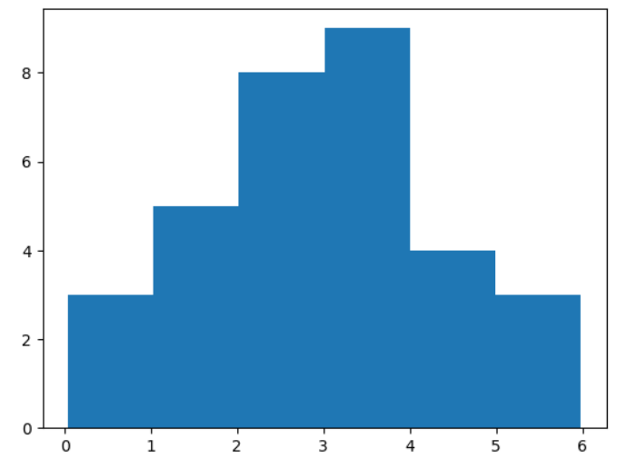

Figure 1 Example of histogram

Preparing a histogram based on those previously prepared data.

The matplotlib library can be used to prepare the histogram. Assume that the data has been stored as: parameter_values=[4.82,3.09,2.03,4.05,2.48,1.3,3.84,2.54,0.32,3.28,4.55,4.38,2.89,5.98,1.2,3.36,0.04,3.03,2.43,3.32,2.56,0.95,3.97,1.93,2.15,1.57,5.11,2.79,3.72,5.52,1.53,2.28]

```python
#import library
import matplotlib.pyplot as plt
# data set
parameter_values=[4.82,3.09,2.03,4.05,2.48,1.3,3.84,2.54,0.32,3.28,4.55,4.38,2.89,5.98,1.2,3.36,
                  0.04,3.03,2.43,3.32,2.56,0.95,3.97,1.93,2.15,1.57,5.11,2.79,3.72,5.52,1.53,2.28]
```

To prepare a histogram, use the function .hist(data,number_of_ranges), where data is the data we want to prepare, number_of_ranges the number of ranges the data will be divided into. The colour parameter allows the default colour of the histogram to be changed. Check what happens if you delete this parameter. Functions xlabel and ylabel allow insert to the generated histogram descriptions of z nad y axe respectively

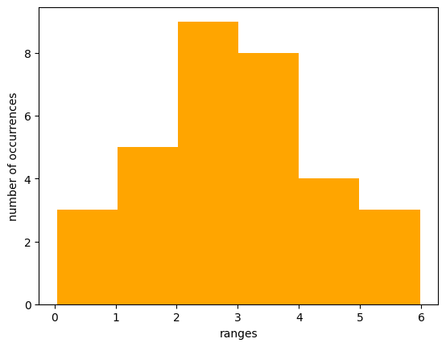

```python
#example of use
plt.hist(parameter_values,6, color = "orange")
plt.xlabel('ranges')
plt.ylabel('number of occurrences')
plt.show()
```

1. Prepare histogram for a give data (parameter_values) run above cell
2. Examine how the histogram changes as a function of the number of ranges into which the data are divided. Record your observations in a report. Prepare three new histograms (insert new cells bellow this)

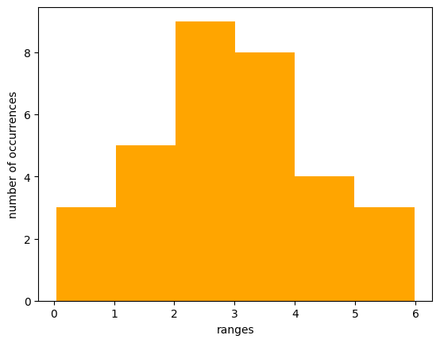

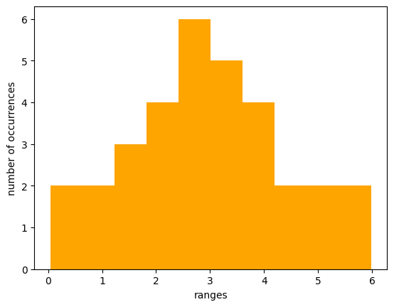

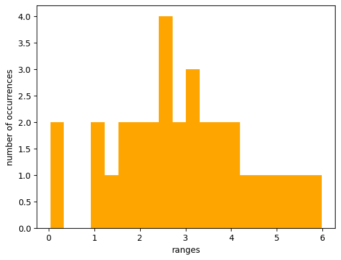

```python
def draw(data, number_of_ranges):
    plt.hist(data, number_of_ranges, color = "orange")
    plt.xlabel('ranges')
    plt.ylabel('number of occurrences')
    plt.show()

draw(parameter_values, 6)
draw(parameter_values, 10)
draw(parameter_values, 20)
```

3. Prepare your own dataset and plot a histogram for them for 5 data intervals

```python
data = [
    0, 0.1, 0.9, 1, 1.1, 1.15, 1.5, 1.9, 2, 3.1, 3.7, 3.9, 4.1, 4.2, 4.3, 4.7, 5, 5.4, 5.9, 6.6, 7.5, 8, 8.5, 9, 9.5, 10
]
```

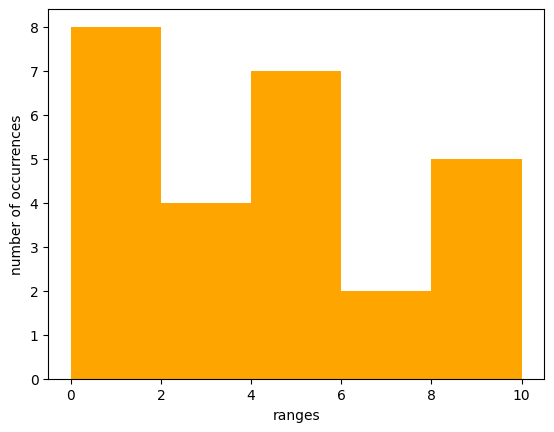

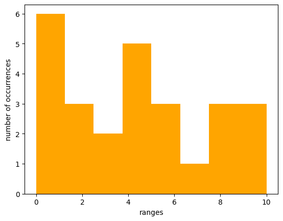

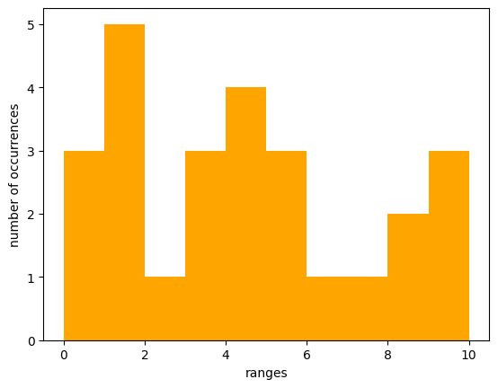

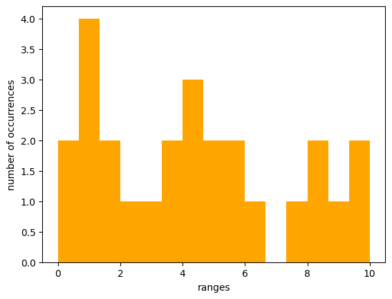

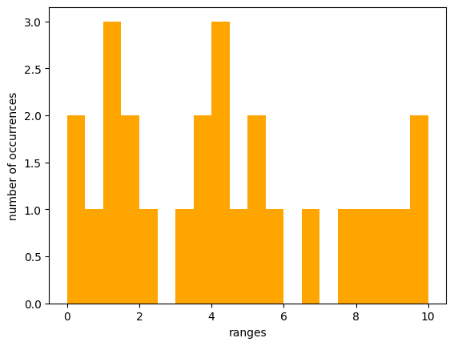

```python
draw(data, 5)
draw(data, 8)
draw(data, 10)
draw(data, 15)
draw(data, 20)
```

# Exercise 2 - Preparation of a histogram based on the data extracted from the file

Six sample data files were prepared for the exercise: data_d01_01.txt, data_d01_02.txt, data_d01_03.txt, data_d02_01.txt, data_d02_02.txt and data_d02_03.txt

During the exercise you will use the files data_d01_01.txt, data_d01_02.txt, data_d01_03.txt or data_d02_01.txt, data_d02_02.txt and data_d02_03.txt. Ask the class instructor which files you should use.

The following cell shows an example in which data has been taken from a sample file. The len() function can be used to check how much data has been downloaded and the head() function can be used to display the first few values.

```python
import numpy as np
import pandas as pd
pd.options.display.max_rows = 9999
data_file = pd.read_csv('data_d02_03.txt')

#display imported data and check how many numbers have been imported
#use len command len(data_file)
len(data_file)

#display the first few values read from the file
data_file.head()

column_key = data_file.columns[0]
data_values = data_file[column_key].tolist()
data_values.insert(0, int(column_key))
print(data_values)
```

```
[7, 43, 38, 37, 5, 62, 42, 47, 92, 66, 22, 41, 53, 41, 85, 79, 96, 29, 22, 9, 84, 37, 82, 14, 21, 9, 95, 48, 97, 3, 55, 91, 100, 65, 76, 18, 50, 14, 33, 4, 56, 26, 60, 1, 55, 42, 99, 50, 82, 37, 65, 31, 97, 32, 52, 83, 2, 54, 88, 1, 80, 43, 25, 10, 55, 30, 65, 4, 84, 30, 75, 63, 22, 71, 41, 93, 19, …
```

```python
def get_values_from_file(filename):
    data_file = pd.read_csv(filename)
    column_key = data_file.columns[0]
    data_values = data_file[column_key].tolist()
    data_values.insert(0, float(column_key))
    return data_values
```

Take the data from the files indicated by your instructor. Prepare a separate histogram for each file.

Determine the distribution of the data, how the data from each file differs.

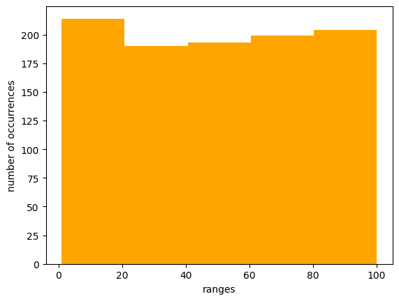

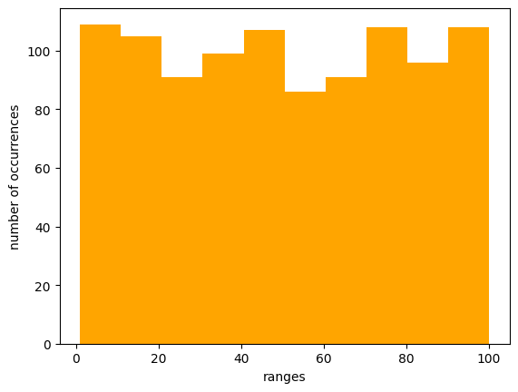

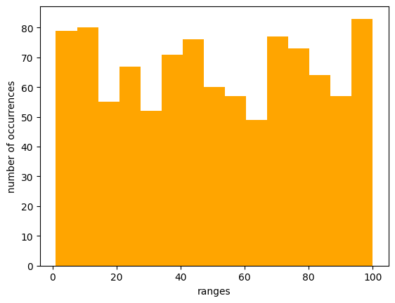

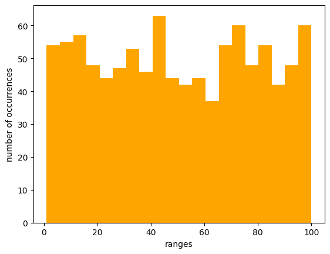

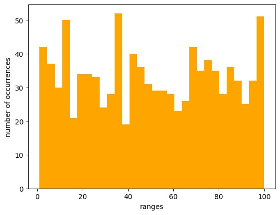

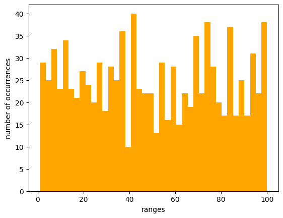

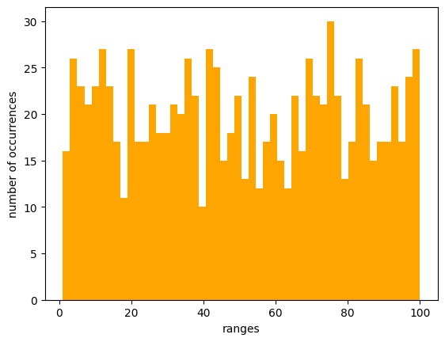

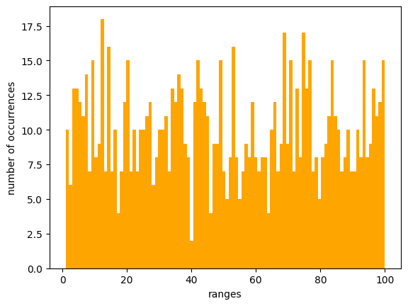

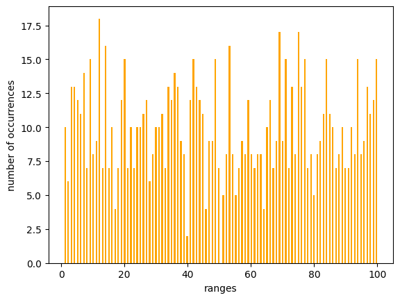

```python
# code
draw(data_values, 5)
draw(data_values, 10)
draw(data_values, 15)
draw(data_values, 20)
draw(data_values, 30)
draw(data_values, 40)
draw(data_values, 50)
draw(data_values, 100)
draw(data_values, 200)
```

### Your observations

Data appears to be randomly generated with quite a lot of variance in histogram bar height. Looking at histograms with lowest number of ranges tells us that the lowest occurence happens in values around 50-70.

# Exercise 3 - Expected value, mode, median and standard deviation

For data obtained from different measurements, the mean, mode and median can be determined. To calculate that parameters we should use statistics library.

The expected value is the arithmetic mean of a large number of independently selected outcomes of a random variable.

The median is the middle value of the data that we have ordered from smallest to largest.

The mode is the value that occurs most frequently in the data set.

Standard deviation - the classic measure of variability, next to the arithmetic mean, the most widely used statistical concept. Intuitively speaking, the standard deviation tells you how widely the values of some quantity (for example, age, inflation, exchange rate) are scattered around its mean.

Determine the expected value from the data collected (parameter_values): x_mean = statistics.mean(parameter_values)

Determine the median from the data collected (parameter_values): x_median = statistics.median(parameter_values)

Determine the mode value from the data collected danych (parameter_values): x_mode = statistics.mode(parameter_values)

Determine the standard deviation from the data collected danych (parameter_values): x_st_dev= statistics.stdev(parameter_values)

As an example, the cell below shows how the mean() function is used to calculate the mean value for data stored in the parameter_values

```python
import statistics
parameter_values_mean = statistics.mean(parameter_values)
print("The average (mean) value is: \n", parameter_values_mean)
```

```
The average (mean) value is:
 2.9065625
```

1. Calculate the remaining parameters for the parameter_value data and for the dataset you created
2. Calculate the parameters for the dataset created by yourself

Save the code in the cell below (for convenience, you can reassemble the calculation of each parameter in a separate cell)

3. Calculate the parameters for the dataset read from files indicated by your instructor.

```
parameter_values
Parameter           Value
----------------------------------------
Mean                2.9065625
Median              2.84
Mode                4.82
Standard Deviation  1.4533090370798858
```

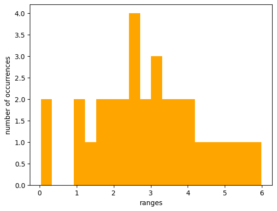

```
my_data
Parameter           Value
----------------------------------------
Mean                4.348076923076923
Median              4.15
Mode                0
Standard Deviation  3.0494747340888324
```

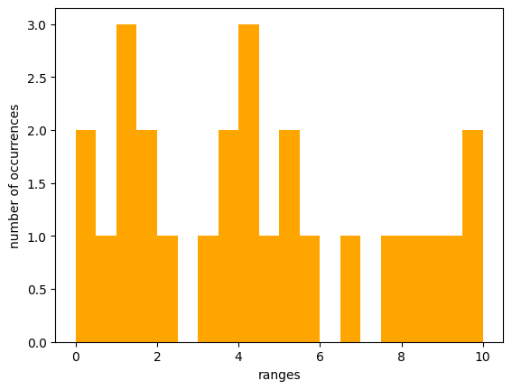

```
data_d01_01.txt
Parameter           Value
----------------------------------------
Mean                10.209873335005005
Median              7.1771
Mode                14.0746
Standard Deviation  10.355048105301684
```

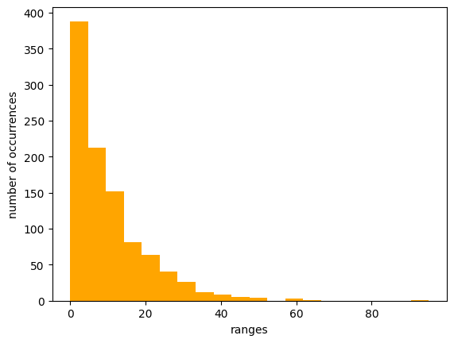

```
data_d01_02.txt
Parameter           Value
----------------------------------------
Mean                1.0209873335005004
Median              0.71771
Mode                1.40746
Standard Deviation  1.0355048105301683
```

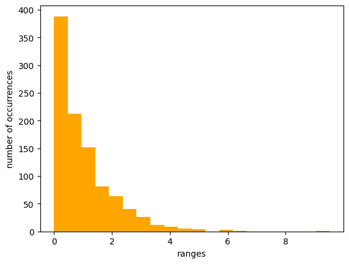

```
data_d01_03.txt
Parameter           Value
----------------------------------------
Mean                2.041974601005005
Median              1.43542
Mode                2.81492
Standard Deviation  2.071009721275076
```

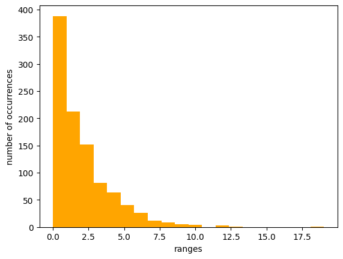

```
data_d02_01.txt
Parameter           Value
----------------------------------------
Mean                1.0
Median              1.0
Mode                1.0
Standard Deviation  0.0
```

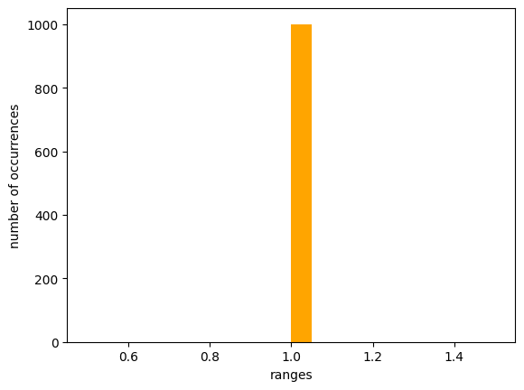

```
data_d02_02.txt
Parameter           Value
----------------------------------------
Mean                5.484
Median              5.0
Mode                1.0
Standard Deviation  2.929902443483115
```

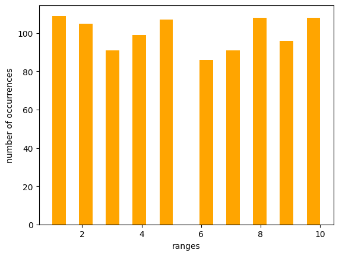

```
data_d02_03.txt
Parameter           Value
----------------------------------------
Mean                50.302
Median              49.0
Mode                12
Standard Deviation  29.488750098679706
```

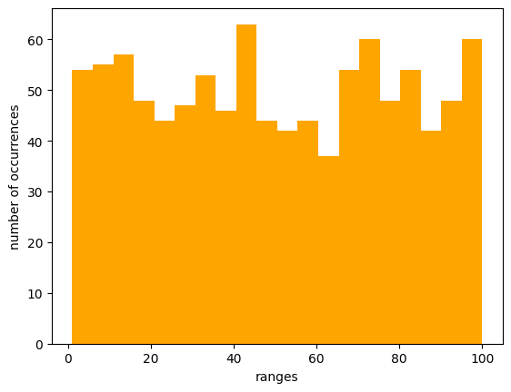

```python
import statistics
import os
def print_parameters(values, title):
    mean = statistics.mean(values)
    median = statistics.median(values)
    mode = statistics.mode(values)
    stdev = statistics.stdev(values)

    print(f"\n{title}")
    print(f"{'Parameter':<20}{'Value':<20}")
    print(f"{'-'*40}")
    print(f"{'Mean':<20}{mean:<20}")
    print(f"{'Median':<20}{median:<20}")
    print(f"{'Mode':<20}{mode:<20}")
    print(f"{'Standard Deviation':<20}{stdev:<20}")
    draw(values, 20)

def get_all_data_files():
    return [f for f in os.listdir(os.getcwd()) if f.endswith('.txt')]

# Calculate the remaining parameters for the parameter_value data and for the dataset you created
print_parameters(parameter_values, "parameter_values")

# Calculate the parameters for the dataset created by yourself
print_parameters(data, "my_data")

# Calculate the parameters for the dataset read from files indicated by your instructor.
for data_file_txt in get_all_data_files():
    values = get_values_from_file(data_file_txt)
    print_parameters(values, data_file_txt)
```

## your observations

### data_d01_01.txt

Almost all of data resides in 0-20 range with most of it in near 0. Outliers with values > 50 push the mean to 10 which looks surprising.

### data_d01_03.txt

Another exponentially-decreasing list of numbers but with a bigger range of values (0-10) and small outliers no-bigger than 20.

### data_d02_01.txt

Only ones in this file.

### data_d02_02.txt

Random spread of integers from 0 to 10.

### data_d02_03.txt

Randomly generated values from 0 to 100 with both mean and median close to ~50.

# Exercise 4 - Generation of data with a given distribution

The numpy library can be used to generate numbers with a given distribution (import numpy as np).

- uniform distribution: x = np.random.uniform(low, high, size) - (low - Lower boundary of the output interval, high - Upper boundary of the output interval, size - number of samples)
- normal distribution: x = np.random.normal(loc, sd, size) - loc - mean (“centre”) of the distribution, sd - Standard deviation (spread or “width”) of the distribution, size - number of samples.
- exponential distribution: x = np.random.exponential(scale, size) - scale - distribution parameter, size - number of samples.

1 Generate sample sets of numbers with a given distribution and parameters (uniform, normal and expotential). Prepare histograms for different intervals.

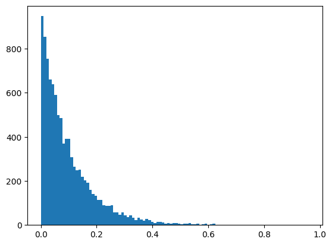

```python
import numpy as np
x =  np.random.exponential(0.1, 10000)
plt.hist(x,100)
```

```
Uniform Distribution
Parameter           Value
----------------------------------------
Mean                5.072160335420151
Median              5.2653218851163395
Mode                5.169891556074141
Standard Deviation  2.862663013203406
```

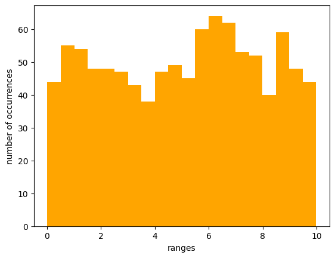

```
Normal Distribution
Parameter           Value
----------------------------------------
Mean                4.893577297012546
Median              4.9340111897801755
Mode                2.990272270904648
Standard Deviation  2.0419296117928805
```

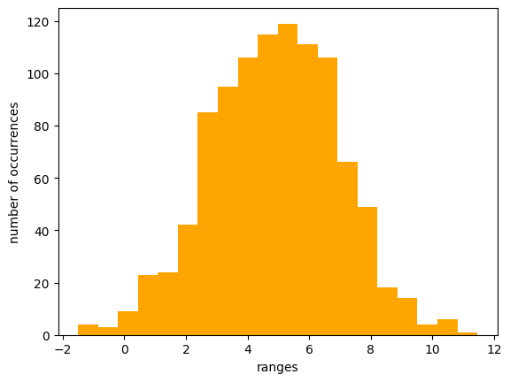

```
Exponential Distribution
Parameter           Value
----------------------------------------
Mean                0.9626583420074453
Median              0.6792168576490525
Mode                0.10324684895164711
Standard Deviation  0.9633308436797058
```

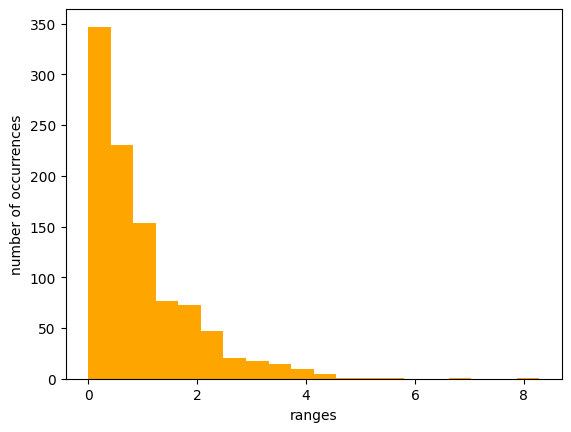

```python
# Generate sample sets of numbers with a given distribution and parameters (uniform, normal and expotential). Prepare histograms for different intervals.

# Generate uniform distribution data
uniform_data = np.random.uniform(low=0, high=10, size=1000)
print_parameters(uniform_data, "Uniform Distribution")

# Generate normal distribution data
normal_data = np.random.normal(loc=5, scale=2, size=1000)
print_parameters(normal_data, "Normal Distribution")

# Generate exponential distribution data
exponential_data = np.random.exponential(scale=1, size=1000)
print_parameters(exponential_data, "Exponential Distribution")
```

## your observations

### Uniform Distribution

Data is evenly spread across the entire range from 0 to 10.

### Normal Distribution

Data is centered around the mean value of 5 with a standard deviation of 2. Histogram shows a bell-shaped curve.

### Exponential Distribution

Histogram shows a steep decline, with most of the values falling into 0-2 range.